# Cutting Edge Reproducibility in Economics

2022-02-11

## Overview

### Problems with computational reproducibility

- Software changes
- Packages
- Inconsistencies across steps
- Adapting to confidential / big data

### Solutions seldomly used

- Regular/automated recomputations
- Packaging of software as part of the computational artifacts

Along for the ride

- Greater efficiency during project development

## OK… but: open-source software has great versioning tools!

## True.

- [`renv`](https://rstudio.github.io/renv/)
- [`packrat`](https://rstudio.github.io/packrat/)
- Package repositories ([`mran`](https://mran.microsoft.com/timemachine), [Rstudio Public Package Manager](https://packagemanager.rstudio.com/client/#/))
- [`Project.toml` and `Manifest.toml`](https://pkgdocs.julialang.org/v1/toml-files/)

## A partial Solution

The various package managers in open source software can be a **partial** solution, when properly implemented.

- Caveats: availability of packages that are being installed (hosted on Github!)

The discussion here today is *one* way to implement them, which promotes highly reproducible *system* setup to support reproducibility. But it also works for *any* set of software packages, with or without package manager.

However, it does not *require* any [one of the above] package managers.

## Illustration: Part of the problem

To make the package managers complete, users need to specify versions of the underlying software as well as of the package.

*Insufficient*

```r
install.packages("superreg")
```

*Better* but **almost never used**

```r
remotes::install_version("superreg",version = "1.2.3")
```

## Part of the problem

*Much better* but almost **never** used

```r
if ( R.Version()$major >= 4 & R.Version()$minor >= 0.5 ) {
remotes::install_version("superreg",version = "1.2.3")
}
```

## Fine… but: proprietary code!

## Proprietary code

None of what follows requires open-source software, nor is invalidated by proprietary software.

With one caveat: **“License rot”**

## Everything here also works with proprietary code

- But it can be more complicated
- I will show “easy-to-use” *Stata*
- Works with MATLAB, Intel compilers, Gurobi optimizer,…

## Best practices and Containers

## Imposes some best practices

### Best practices

- Master script preferred
- No manual copying of results
- No manual install of packages
- Use platform-neutral path names (`c/myprojects/thisone` instead of `C:\myprojects\thisone`)

### Here

- Master script *required*
- Results *must* be written out programmatically
- All packages must be installed by scripts*
- Naturally imposes forward-slashes*

## An example: R with API and big data

## An example: R with API and big data

We will use an example which has the following features:

- it uses big data,
- it has one private parameter (an API key) that we do not want to put out there.

How can we get this to be

- robust
- repeatable
- push-button
- in the cloud

## Context

We will use **U.S. Census Bureau data** (American Community Survey data) through an API. Downloading the entire corpus of ACS data would consume multiple **100 GB**, but the API allows us to slice and dice the data.

The example we will use will artificially reduce the amount of data for illustrative purposes, but we identify how this simple example becomes a “big data” example.

The full example can be found here ([R source](https://github.com/labordynamicsinstitute/bitss-cutting-edge-2022/blob/main/part3.Rmd)). Refer to it for full requirements and reproducibility setup, as well as how to scale from the toy example to the full setup.

## Confidential parameters in regular use

Here, we use the `~/.Renviron` file (in my home directory, outside of the project directory), though I won’t show you my actual file. Here’s what the package documentation says

```r
census_api_key("111111abc", overwrite = TRUE, install = TRUE)
# First time, reload your environment so you can use the key without restarting R.
readRenviron("~/.Renviron")
# You can check it with:
Sys.getenv("CENSUS_API_KEY")
```

To reproduce this, [obtain a Census API key](http://api.census.gov/data/key_signup.html), and run the code above. We can then set the API key for the `tidycensus` package.

```r
if ( file.exists("~/.Renviron") ) { readRenviron("~/.Renviron") }
census_api_key(Sys.getenv("CENSUS_API_KEY"))
```

```
## To install your API key for use in future sessions, run this function with `install = TRUE`.
```

## Trivial example

We’re going to adapt the “[Basic Usage tutorial](https://walker-data.com/tidycensus/articles/basic-usage.html)” from the `tidycensus` website, and compute the median age by county for 2010 (but for illustration, we’ll cut it down).

Let’s see this for one county: Tompkins county (FIPS code “36109”)

```r
age10block <- get_decennial(geography = "block", state="NY", county="109",
                            show_call=FALSE,
                       variables = "P013001",year = 2010)
```

```
## Using Census Summary File 1
```

## Trivial example

That took **0.8 seconds**. It generated 3082 observations.

For ONE county. There are *3237* counties in total.

```r
# Set the number of counties to query
counties.to.query <- 30
# if we wanted all of this, we would replace the number with "nrow(fips_codes)"
# counties.to.query <- nrow(fips_codes)
```

Let’s see how long this takes for the first 30 counties.

## Big data

```r
# tidycensus/Census API forces to loop over counties
start.time <- Sys.time()
blocks <- NA
for (row in 1:counties.to.query ) {
  county <- fips_codes[row,"county_code"]
  state  <- fips_codes[row,"state"]
  thisblock <- get_decennial(geography = "block",state=state,county=county,
                       variables = "P013001",year = 2010)
  # collect the data
  if ( row == 1 ) {
    blocks <- thisblock
    rm(thisblock)
  } else {
    blocks <- bind_rows(blocks,thisblock)
    rm(thisblock)
  }
}
```

[output not shown]

[output not shown]

[output not shown]

[output not shown]

[output not shown]

[output not shown]

[output not shown]

[output not shown]

[output not shown]

[output not shown]

[output not shown]

[output not shown]

[output not shown]

[output not shown]

[output not shown]

[output not shown]

[output not shown]

[output not shown]

[output not shown]

[output not shown]

[output not shown]

[output not shown]

[output not shown]

[output not shown]

[output not shown]

[output not shown]

[output not shown]

[output not shown]

[output not shown]

[output not shown]

```r
end.time <- Sys.time()
elapsed.time <- end.time - start.time
elapsed.scale <- round(elapsed.time / counties.to.query * nrow(fips_codes),1)
```

## Big data

That took **18.36 seconds** for 30 of 3237 counties, yielding 84042 records.

Estimated total time will be approximately **33 minutes** on **my Intel(R) Xeon(R) Platinum 8171M CPU @ 2.60GHz-based system.**

## Possible problems

## Possible problems

- API breaks
- Package breaks
- My code breaks

## How to detect problems early?

## Continous Integration

[figure not shown]

CI

## Continous Integration

Continuous Integration (CI) is the process of automating the build and testing of code every time a team member commits changes to version control. [[*](https://docs.microsoft.com/en-us/devops/develop/what-is-continuous-integration)]

[figure not shown]

CI

## Continous Integration

### Basic principle:

- Write code
- Run code **every time** a change is made
- Detect and adjust problems (tests)

## … But: Code runs **33** minutes!

## Relax.

## Setting up cloud computing

## Setting up cloud computing

In this example,

- Github
- Github Actions
- API key as a `Github Actions Secret`
- Docker container

## What is…

### Github

*Hosted git repository* (could be Gitlab, Bitbucket, others)

### Github Actions:

Github’s “*Continuous Integration*” solution  
(could be Gitlab CI, Bitbucket Pipelines, Travis CI, others)

### Github Actions Secret

A private way to *securely store information* (here: the API key) in the cloud, to be used by online solutions such as Github Actions

### Docker

A container solution, underlying much of the current internet  
(Github Actions, Netflix, various other solutions)

## Docker

### Docker are (linux) containers

I have [written about Docker in Economics](https://aeadataeditor.github.io/posts/2021-11-16-docker) before.

Containers are “implementations of operating system-level virtualization,”<sup>1</sup> typically on Linux… “packages up code and all its dependencies so the application runs quickly and reliably from one computing environment to another.”<sup>2</sup>

[figure not shown]

Docker home

## Singularity

I’m going to focus on Docker (more common in the commercial world), but there are other implementations, such as [Singularity](https://singularity.hpcng.org/), and a [common standard for “container” specifications/structure.](https://www.opencontainers.org/)

[figure not shown]

Syslabs page

## Docker in Economics is rare

The use of containers as part of replication packages in economics is **extremely low**.

For an excellent introduction, see Boettinger (2015) <sup>3</sup>.

## Basic principle

**Isolation**: means that

- in principle all dependencies are handled (at build time)
- there should be virtually no differences across
  - time,
  - users’ environment (operating system, system settings)
  - software implementation

in reproducing the outcomes of software.

### Caveat

If your software accesses the internet, then things can change over time.

## Containers and reproducibility

Containers **can** therefore, but **do not necessarily**, contribute to reproducibility and replicability.

## Containers once created …

- can (should) reliably reproduce the context and output they were designed to handle.

### Reproducibility of containers themselves

- typically use a plain-text script for their creation (so-called `Dockerfile`)
  - contributes to transparency.

## Caveats for Reproducibility

### Interactive creation

Containers **can** be interactively created, or incorporate externally created packages (internet access), and then saved, which may lead to some black-box actions that are not transparent.

> Thus, containers can generate reproducible output, but not be themselves reproducibly created.

### Dynamics updates

If containers rely on external resources

- for instance, accessing the internet to download data from an API,
- install “latest” packages

the output generated may not be reproduced, though it may still be considered **replicable.**

```r
update.packages(ask = FALSE)
```

## Containers in computational social science

For the (social science) research environment, this should, in principle, handle many of the common problems that workarounds and READMEs list. Uses

- Run R through a container
- Run Intel Fortran (or another complex setup) through container
- Run Gurobi through container with a dynamic license
- The Holy Grail in **Economics**: Run Stata through a container

## Running R, Julia, Python in Docker

Most examples on internet use containers in conjunction with open-source languages: R, Python, Julia, etc.

## A Really Simple Example with R

## Specifying a container

- [`Dockerfile`](https://github.com/AEADataEditor/docker-r-starter/blob/main/Dockerfile):

```
FROM rocker/r-ver:4.0.1
COPY setup.R .
RUN Rscript setup.R
```

That’s already all there is to defining a Docker image for a project!

### NOTE

- We leverage an existing image (official [rocker](https://hub.docker.com/u/rocker/) maintaining containers for R)
- Best practice: a `setup.R` script to initialize the environment

## Creating a container

Of course, it now needs to be built:<sup>4</sup>

```bash
TAG=v$(date +%F)
MYIMG=bitss-cutting-edge-2022
MYHUBID=larsvilhuber
DOCKER_BUILDKIT=1 docker build . -t $MYHUBID/$MYIMG:$TAG
```

or simply

`docker build . -t larsvilhuber/bitss-cutting-edge-2022:2022-02-10`

```bash
[+] Building 4.7s (17/17) FINISHED
 => [internal] load build definition from Dockerfile                       0.0s
 => => transferring dockerfile: 37B                                        0.0s
...
 => exporting to image                                                     0.0s
 => => exporting layers                                                    0.0s
 => => writing image sha256:73cf6ac6b5a8a84f72fff729879b46d14340352761bb1580.0s
 => => naming to docker.io/larsvilhuber/bitss-cutting-edge-2022:2022-02-10 0.0s
```

This locks in our R environment, at the time of building (`$TAG`). It is then straightforward to run code, reliably, over and over again.

## Sharing container

I can upload it to Docker Hub, where anybody can now use it:

```bash
docker push larsvilhuber/bitss-cutting-edge-2022:2022-02-10
```

(reproducibility!)

## Running a container

All we need is Docker as a software installation on our **workstation.**

```bash
cd path/to/code
docker run --rm \
   -v $(pwd)/subdir:/code \
   -w /code $MYHUBID/${MYIMG}:$TAG \
   Rscript main.R
```

## Or: in the cloud.

[figure not shown]

## Setting up cloud computing

In this example,

- Github - *to store the code*
- Github Actions - *to run the code/container*
- API key as a `Github Actions Secret` - *to be able to access data*
- Docker container - *to ensure speed and reproducibility*

NOTE: The container is not strictly needed, but ensures that we do not *HAVE* to use the cloud to run this!

## Example: this presentation

- **Github**
- **Github Actions**
- API key as a `Github Actions Secret`
- Docker container

[labordynamicsinstitute/bitss-cutting-edge-2022/…/workflows/main.yml](https://github.com/labordynamicsinstitute/bitss-cutting-edge-2022/blob/main/.github/workflows/main.yml)

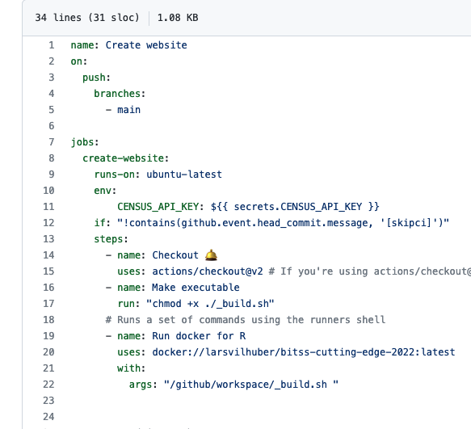

## Example: this presentation

- Github
- Github Actions
- **API key as a `Github Actions Secret`** ([how](https://docs.github.com/en/actions/security-guides/encrypted-secrets))
- Docker container

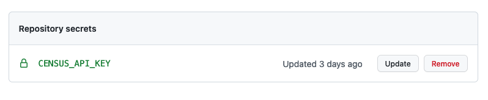

repo-secret

## Example: this presentation

- Github
- Github Actions
- API key as a `Github Actions Secret`
- **Docker container** (Dockerfile)

[figure not shown]

Image on Docker Hub

## Example: this presentation

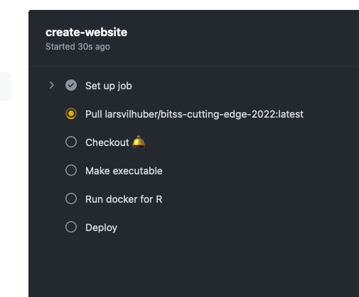

## Example: this presentation

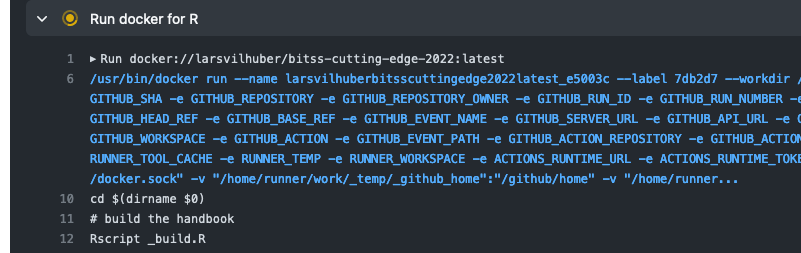

## Can you make that easier?

```
[+] Building 829.1s (13/13) FINISHED
 => [internal] load build definition from Dockerfile                         0.0s
 => => transferring dockerfile: 751B                                         0.0s
 => [internal] load .dockerignore                                            0.2s
 => => transferring context: 2B                                              0.0s
 => [internal] load metadata for docker.io/rocker/verse:4.0.5                1.1s
 => [auth] rocker/verse:pull token for registry-1.docker.io                  0.0s
 => [1/7] FROM docker.io/rocker/verse:4.0.5@sha256:a4ce6ebbe27d70c98645f765  0.0s
 => [internal] load build context                                            0.1s
 => => transferring context: 1.52kB                                          0.0s
 => CACHED [2/7] RUN apt-get update     && DEBIAN_FRONTEND=noninteractive a  0.0s
 => CACHED [3/7] WORKDIR /home/rstudio                                       0.0s
 => [4/7] COPY libraries-src.R install-src.R                                 0.0s
 => [5/7] COPY libraries.R install.R                                         0.0s
 => [6/7] RUN Rscript install-src.R                                        788.5s
 => [7/7] RUN Rscript install.R                                             37.5s
 => exporting to image                                                       1.2s
 => => exporting layers                                                      1.2s
 => => writing image sha256:73cf6ac6b5a8a84f72fff729879b46d14340352761bb158  0.0s
```

## Sure.

## Running Docker the Easy Way

Of course, this may all seem overwhelming and complicated, as any new piece of software. Which is why several services are available that make this all a lot easier.

- [CodeOcean](https://codeocean.com/)
- [WholeTale](https://wholetale.org/)
- [Binder](https://mybinder.org/),

and others (see Konkol et al, 2020,<sup>5</sup> for a broader overview).

Behind the scenes, these use containers as well, sometimes built on the fly, but also able to archive the containers, ensuring persistence of what hopefully are reproducible containers.

## But: Continuous Integration

Most of the user-friendly online systems are meant to be interactive.

- CodeOcean has a “button” to test push-button reproducibility

[figure not shown]

Reproducible but not CI.

## But: Portability

When run on my Linux Workstation:

```
Replicator system
-----------------
* "openSUSE Leap 15.3"
* AMD Ryzen 9 3900X 12-Core Processor, 24 cores , 31GB memory
* Docker version 20.10.12-ce, build 459d0dfbbb51
```

When run on my MacBook

```
Replicator system
-----------------
* macOS 12.1 (Darwin version 21.2.0)
* Intel(R) Core(TM) i5-7267U CPU @ 3.10GHz ,  2  cores,  8 GB memory
* Docker version 20.10.12, build e91ed57
```

When run in a cloud system

```
Replicator system
-----------------
* "Ubuntu 20.04.3 LTS"
* model name : Intel(R) Xeon(R) Platinum 8272CL CPU @ 2.60GHz ,  2  cores,  3 GB memory
* Docker version 20.10.11+azure-3, build dea9396e184290f638ea873c76db7c80efd5a1d2
```

## You promised us Stata!

[figure not shown]

Stata GUI

## OK, but here’s where I’ll lose a few folks

## Stata command line

[figure not shown]

Stata Terminal

## Stata command line

- No manual saving of figures
- No data browsing or manual edits of data

But you weren’t using any of those things anyway, right? Right?

## Setting up cloud computing: Stata

For this example,

- Github - *to store the code*
- Github Actions - *to run the code/container*
- License key as a `Github Actions Secret` - *to be able to run Stata*
- Docker container - *to ensure speed and reproducibility* **and not need to install Stata every time**

NOTE: [Project is here](https://github.com/labordynamicsinstitute/sample-project-stata).

## Example: Stata example

- **Github**
- **Github Actions**
- API key as a `Github Actions Secret`
- Docker container

[github.com/labordynamicsinstitute/sample-project-stata/…/workflows/compute.yml](https://github.com/labordynamicsinstitute/sample-project-stata/blob/main/.github/workflows/compute.yml)

```yaml
     - name: Create license
        run: |
            echo "${{ secrets.STATA_LIC_BASE64 }}" | base64 -d > stata.lic
            ls -l stata.lic
      # Compute the main result, re-using the run.sh script
      -  name: Compute
         run: "bash -x ./run.sh ./stata.lic"
```

## Example: Stata example

- Github
- **Github Actions** - wrapper around the Docker call
- API key as a `Github Actions Secret`
- Docker container

```bash
time docker run $DOCKEROPTS \
  -v ${STATALIC}:/usr/local/stata/stata.lic \
  -v $(pwd)/${codedir}:/code \
  -v $(pwd)/data:/data \
  $DOCKERIMG:$TAG -b $basefile
```

## Example: Stata example

- Github
- Github Actions
- **API key as a `Github Actions Secret`** ([how](https://docs.github.com/en/actions/security-guides/encrypted-secrets) and [how](https://github.com/AEADataEditor/stata-project-with-docker#setting-up-github-actions-and-configure-the-stata-license-in-the-cloud))
- Docker container

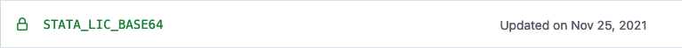

repo-secret

```bash
 gh secret set STATA_LIC_BASE64 -b"$(cat stata.lic | base64)" -v all -o YOURORG
```

## Example: Stata example

- Github
- Github Actions
- API key as a `Github Actions Secret`
- **Docker container** (Using a general container here without modification - note: no official Stata image!)

[figure not shown]

Image on Docker Hub

## Example: Stata example

[figure not shown]

## Example: Stata example

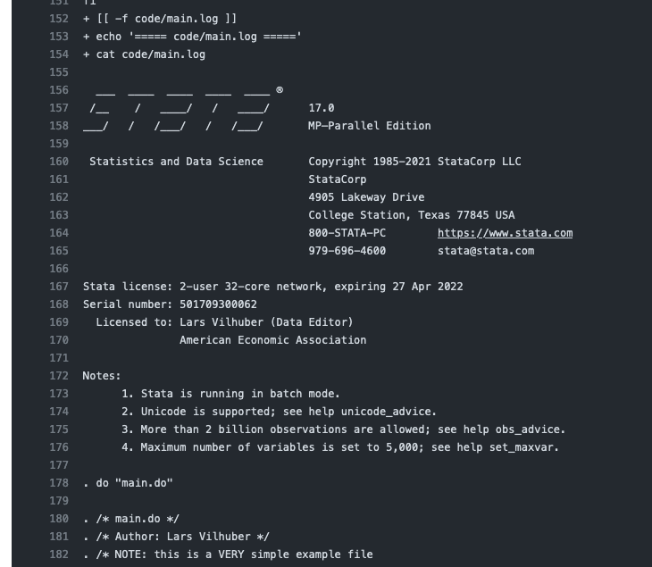

## Example: Stata example

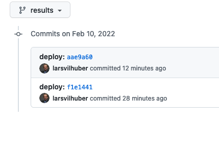

## Example: Stata example

[figure not shown]

## Detailed tutorial

https://github.com/AEADataEditor/stata-project-with-docker

[figure not shown]

guidance

## REALLY: Can you make that easier?

```
[+] Building 829.1s (13/13) FINISHED
 => [internal] load build definition from Dockerfile                         0.0s
 => => transferring dockerfile: 751B                                         0.0s
 => [internal] load .dockerignore                                            0.2s
 => => transferring context: 2B                                              0.0s
 => [internal] load metadata for docker.io/rocker/verse:4.0.5                1.1s
 => [auth] rocker/verse:pull token for registry-1.docker.io                  0.0s
 => [1/7] FROM docker.io/rocker/verse:4.0.5@sha256:a4ce6ebbe27d70c98645f765  0.0s
 => [internal] load build context                                            0.1s
 => => transferring context: 1.52kB                                          0.0s
 => CACHED [2/7] RUN apt-get update     && DEBIAN_FRONTEND=noninteractive a  0.0s
 => CACHED [3/7] WORKDIR /home/rstudio                                       0.0s
 => [4/7] COPY libraries-src.R install-src.R                                 0.0s
 => [5/7] COPY libraries.R install.R                                         0.0s
 => [6/7] RUN Rscript install-src.R                                        788.5s
 => [7/7] RUN Rscript install.R                                             37.5s
 => exporting to image                                                       1.2s
 => => exporting layers                                                      1.2s
 => => writing image sha256:73cf6ac6b5a8a84f72fff729879b46d14340352761bb158  0.0s
```

## Sure. For Stata, too.

## Running Docker the Easy Way: Stata

For Stata (and MATLAB), the choices are a bit shorter:

- [CodeOcean](https://codeocean.com/)
- [WholeTale](https://wholetale.org/)

but also

- [Github Action template for Stata](https://github.com/labordynamicsinstitute/continuous-integration-stata) based on excellent work by [Lukman Edwindra](https://github.com/ledwindra).
  - May be easier to set up
  - (Currently) does not use the Docker images, takes longer (uses the URL where you downloaded Stata to install it)

## Outlook

## Use by AEA Data Editor team

I am piloting this with some cases to enable reproducibility verification in a shareable and repeatable environment

- Dinkelman and Ngai (JEP, Feb 2022)<sup>6</sup>: [Github repo](https://github.com/AEADataEditor/JEP-2021-1239) and [Docker image](https://hub.docker.com/r/aeadataeditor/jep-2021-1239)
- DellVigna and Pope (AEJ:Micro, forthcoming)<sup>7</sup>: [CodeOcean capsule](https://doi.org/10.24433/CO.0687784.v1) and its copy to openICPSR (https://doi.org/10.3886/E135221V1)
- Rossi (JEL, Feb 2022)<sup>8</sup>: [CodeOcean capsule](https://doi.org/10.24433/CO.7940775.v1) and its copy to openICPSR (https://doi.org/10.3886/E147225V1).

We are working with the [WholeTale](https://wholetale.org/) on similar usage scenarios, and are open to working with authors’ choices whereever those may lead.

## Use by authors

Example:

- Lamadon, Thibaut, Magne Mogstad, and Bradley Setzler (AER: forthcoming)<sup>9</sup> had **4** (**four**) different CodeOcean capsules to illustrate their analysis (which otherwise used confidential data)
  - Verifying the analysis with confidential data took several months
  - Verifying the results on CodeOcean took minutes
- Bonhomme, Lamadon, and Manresa (forthcoming Econometrica) use Docker with synthetic data

## Use by research data infrastructure

- [BPLIM](https://bplim.bportugal.pt/) permits authors to use Singularity containers in the secure environment.

## Conclusion

### Containers provide a way to make research more reproducible

- even when software requires a license

### While this may be useful for us in the context of reproducibility checks…

- It is far more useful if authors use this **prior** to submission to *any* journal

### Using containers enables continuous integration

- Higher setup costs, but assured reproducibility and portability throughout

## Some downsides

- Complexity in initial setup
- Archaic graphical interfaces (not web-based) don’t work
  - MATLAB now has a web-based interface
  - Rstudio and Jupyter notebooks/ JupyterLab have had for a long time
- Learning curve for non-DS/CS affine students (and faculty)

## Examples in the literature

## Recent or forthcoming papers

- Rossi (JEL, 2022): “Forecasting in the presence of instabilities: How do we know whether models predict”<sup>10</sup>
- DellaVigna and Pope ([forthcoming in American Economic Journal: Microeconomics](https://www.aeaweb.org/articles?id=10.1257/mic.20200129)) “Stability of Experimental Results: Forecasts and Evidence”<sup>11</sup>
- Bonhomme, Lamadon, and Manresa (forthcoming Econometrica): “A distributional Framework for matched employer-employee data”, [Github repository](https://github.com/tlamadon/blm-replicate)

## Resources

See [my blogpost](https://aeadataeditor.github.io/posts/2021-11-16-docker)

[figure not shown]

## The End.

## Extras

## Running Docker locally?

Absolutely.

- For publications, it is very important to keep a record of the computational artifacts (see [AEA Data and Code Availability Policy](https://www.aeaweb.org/journals/data/data-code-policy))

## Running code interactively?

Yes.

- In fact, this presentation is created interactively in the cloud

And yet it **also**

- is run non-interactively in the cloud for each pushed commit ([key configuration line](https://github.com/labordynamicsinstitute/bitss-cutting-edge-2022/blob/867c5c3cc3eb185711744bc2a81827698414a95e/.github/workflows/main.yml#L19) and [example run](https://github.com/labordynamicsinstitute/bitss-cutting-edge-2022/runs/5133378182?check_suite_focus=true))
- can be downloaded (click here to open with Github Client) and run locally

```
source .Renviron
docker run  \
   -e CENSUS_API_KEY=$CENSUS_API_KEY \
   -v "$(pwd)":/home/rstudio \
   --rm  \
   larsvilhuber/bitss-cutting-edge-2022 \
   Rscript _build.R
```